# ENV H 570: Lab 1

Joan A. Casey

26 March, 2025

## Objective

The goal of this lab is to get you acquainted with the online RStudio environment on the SPH server and to introduce you to basic commands to explore data. We’ll be using fetal death data in R and will examine, manipulate, and plot/map the data in order to better understand what it contains. The final part of this lab will walk you through a series of optional steps to create cartograms and run a simple regression model.

## Setup

```r
# Clear workspace of all objects and unload all extra (non-base) packages.
rm(list = ls(all = TRUE))
if (!is.null(sessionInfo()$otherPkgs)) {
  res <- suppressWarnings(
    lapply(paste('package:', names(sessionInfo()$otherPkgs), sep=""),
           detach, character.only=TRUE, unload=TRUE, force=TRUE))
}

# Load packages, installing if needed
if (!requireNamespace("pacman", quietly = TRUE)){
  install.packages("pacman")
  }

pacman::p_load(
  conflicted,
  here,
  usethis,
  Hmisc,
  dplyr,
  readr,
  tidyr,
  explore,
  rlang,
  ggplot2,
  RColorBrewer,
  tmap,
  sf,
  viridis,
  corrr,
  marginaleffects,
  spdep,
  cartogram
)

# Declare a package preference for filter() with `conflicts_prefer()`:
# this is needed because other packages have functions called `filter`
# and we want to make sure we are using dplyr's `filter` function.
# the other way to do this is to type `dplyer::filter` every time we want to
# use filter.
conflicts_prefer(dplyr::filter)
conflicts_prefer(tidyr::expand)
conflicts_prefer(corrr::correlate)
conflicts_prefer(dplyr::select)
```

## Part 1: Fetal death (outcome) data cleaning

### I. Read in and explore outcome data

```r
# Read in outcome data (fetal deaths = "spontaneous intrauterine death of a
# fetus at any time during pregnancy"), downloaded from CDC Wonder:
# https://wonder.cdc.gov/fetal-deaths-current.html
fetal_data <- read_csv(here("data/lab/01/fetal_death.csv"))
# Explore the data using dplyr::glimpse
glimpse(fetal_data)
```

```
## Rows: 356
## Columns: 5
## $ state        <chr> "Alabama", "Alabama", "Alabama", "Alabama", "Alabama", "A…
## $ state_code   <dbl> 1, 1, 1, 1, 1, 1, 1, 1, 2, 2, 2, 2, 2, 4, 4, 4, 4, 4, 4, …
## $ year         <dbl> 2014, 2014, 2015, 2015, 2016, 2016, 2017, 2017, 2014, 201…
## $ mom_race_eth <chr> "Black or African American", "White", "Black or African A…
## $ fetal_deaths <dbl> 269, 253, 273, 268, 262, 288, 268, 269, 32, 10, 21, 46, 3…
```

```r
# Explore the data using summary
summary(fetal_data)
```

```
##     state             state_code         year      mom_race_eth
##  Length:356         Min.   : 1.00   Min.   :2014   Length:356
##  Class :character   1st Qu.:15.75   1st Qu.:2015   Class :character
##  Mode  :character   Median :28.00   Median :2016   Mode  :character
##                     Mean   :28.09   Mean   :2016
##                     3rd Qu.:41.00   3rd Qu.:2016
##                     Max.   :56.00   Max.   :2017
##   fetal_deaths
##  Min.   :  10.0
##  1st Qu.:  55.0
##  Median : 183.0
##  Mean   : 246.8
##  3rd Qu.: 325.5
##  Max.   :1907.0
```

```r
# Explore the data using explore::describe_tbl and explore::describe
explore::describe_tbl(fetal_data)
```

```
## 356 observations with 5 variables
## 0 observations containing missings (NA)
## 0 variables containing missings (NA)
## 0 variables with no variance
```

```r
explore::describe(fetal_data)
```

| variable | type | na | na_pct | unique | min | mean | max |
| --- | --- | --- | --- | --- | --- | --- | --- |
| state | chr | 0 | 0 | 51 | NA | NA | NA |
| state_code | dbl | 0 | 0 | 51 | 1 | 28.09 | 56 |
| year | dbl | 0 | 0 | 4 | 2014 | 2015.51 | 2017 |
| mom_race_eth | chr | 0 | 0 | 2 | NA | NA | NA |
| fetal_deaths | dbl | 0 | 0 | 237 | 10 | 246.80 | 1907 |

```r
# Explore the data using Hmisc::describe
Hmisc::describe(fetal_data)
```

```
## fetal_data
##
##  5  Variables      356  Observations
## --------------------------------------------------------------------------------
## state
##        n  missing distinct
##      356        0       51
##
## lowest : Alabama       Alaska        Arizona       Arkansas      California
## highest: Virginia      Washington    West Virginia Wisconsin     Wyoming
## --------------------------------------------------------------------------------
## state_code
##        n  missing distinct     Info     Mean  pMedian      Gmd      .05
##      356        0       51        1    28.09       28    17.99     4.00
##      .10      .25      .50      .75      .90      .95
##     6.00    15.75    28.00    41.00    50.00    53.25
##
## lowest :  1  2  4  5  6, highest: 51 53 54 55 56
## --------------------------------------------------------------------------------
## year
##        n  missing distinct     Info     Mean  pMedian      Gmd
##      356        0        4    0.937     2016     2016    1.251
##
## Value       2014  2015  2016  2017
## Frequency     88    89    90    89
## Proportion 0.247 0.250 0.253 0.250
##
## For the frequency table, variable is rounded to the nearest 0
## --------------------------------------------------------------------------------
## mom_race_eth
##        n  missing distinct
##      356        0        2
##
## Value      Black or African American                     White
## Frequency                        153                       203
## Proportion                      0.43                      0.57
## --------------------------------------------------------------------------------
## fetal_deaths
##        n  missing distinct     Info     Mean  pMedian      Gmd      .05
##      356        0      237        1    246.8      199    256.9    21.75
##      .10      .25      .50      .75      .90      .95
##    30.00    55.00   183.00   325.50   555.00   652.75
##
## lowest :   10   11   12   13   14, highest: 1487 1747 1814 1883 1907
## --------------------------------------------------------------------------------
```

```r
# How many states are included in the dataset? Find out using n_distinct. Which
# package has the n_distinct command?
n_distinct(fetal_data$state) # 50 states + DC
```

```
## [1] 51
```

### II. Manipulate outcome data to handle missingness

```r
# Some states do not have data for each year/race/death combo
# If table shows two entries for a state, they have counts for both Black and
# white pregnant people
table(fetal_data$state, fetal_data$year)
```

```
##
##                        2014 2015 2016 2017
##   Alabama                 2    2    2    2
##   Alaska                  1    2    1    1
##   Arizona                 2    2    2    2
##   Arkansas                2    2    2    2
##   California              2    2    2    2
##   Colorado                2    2    2    2
##   Connecticut             2    2    2    2
##   Delaware                2    2    2    2
##   District of Columbia    2    2    2    2
##   Florida                 2    2    2    2
##   Georgia                 2    2    2    2
##   Hawaii                  1    1    1    1
##   Idaho                   1    1    1    1
##   Illinois                2    2    2    2
##   Indiana                 2    2    2    2
##   Iowa                    2    2    2    2
##   Kansas                  2    2    2    2
##   Kentucky                2    2    2    2
##   Louisiana               2    2    2    2
##   Maine                   1    1    1    1
##   Maryland                2    2    2    2
##   Massachusetts           2    2    2    2
##   Michigan                2    2    2    2
##   Minnesota               2    2    2    2
##   Mississippi             2    2    2    2
##   Missouri                2    2    2    2
##   Montana                 1    1    1    1
##   Nebraska                2    2    2    2
##   Nevada                  2    2    2    2
##   New Hampshire           1    1    1    1
##   New Jersey              2    2    2    2
##   New Mexico              1    1    1    1
##   New York                2    2    2    2
##   North Carolina          2    2    2    2
##   North Dakota            1    1    2    1
##   Ohio                    2    2    2    2
##   Oklahoma                2    2    2    2
##   Oregon                  2    2    2    2
##   Pennsylvania            2    2    2    2
##   Rhode Island            1    0    1    2
##   South Carolina          2    2    2    2
##   South Dakota            1    1    1    1
##   Tennessee               2    2    2    2
##   Texas                   2    2    2    2
##   Utah                    1    1    1    1
##   Vermont                 1    1    1    1
##   Virginia                2    2    2    2
##   Washington              2    2    2    2
##   West Virginia           1    2    2    1
##   Wisconsin               2    2    2    2
##   Wyoming                 1    1    1    1
```

```r
# Expand so we have a row for each year/race/state combo
# We expect a dataframe 51 states x 4 years x 2 race/ethnicities = 408
# This dataframe does not contain the fetal_deaths but is just a square template
# that we can use to create a dataset that has every state/yr/raceeth combo
# regardless of whether there were fetal deaths or not.
fetal_data_expanded <- fetal_data %>% expand(state, year, mom_race_eth)
dim(fetal_data_expanded)
```

```
## [1] 408   3
```

```r
head(fetal_data_expanded)
```

| state | year | mom_race_eth |
| --- | --- | --- |
| Alabama | 2014 | Black or African American |
| Alabama | 2014 | White |
| Alabama | 2015 | Black or African American |
| Alabama | 2015 | White |
| Alabama | 2016 | Black or African American |
| Alabama | 2016 | White |

```r
# Now we can merge our fetal deaths (`fetal_data`) onto our template
# `fetal_data_new` so we have a row for every state/yr/raceeth combo. We can use
# left join so that we keep all rows from `fetal_data_new` and rows where we
# don't have fetal death data (due to small numbers) will have NAs.
# Please read about left_join by typing ?left_join into the console
fetal_data_new <- left_join(
  fetal_data_expanded,
  fetal_data,
  by = c(
    "state" = "state",
    "year" = "year",
    "mom_race_eth" = "mom_race_eth"
  )
)

# Glimpse it
glimpse(fetal_data_new)
```

```
## Rows: 408
## Columns: 5
## $ state        <chr> "Alabama", "Alabama", "Alabama", "Alabama", "Alabama", "A…
## $ year         <dbl> 2014, 2014, 2015, 2015, 2016, 2016, 2017, 2017, 2014, 201…
## $ mom_race_eth <chr> "Black or African American", "White", "Black or African A…
## $ state_code   <dbl> 1, 1, 1, 1, 1, 1, 1, 1, NA, 2, 2, 2, NA, 2, NA, 2, 4, 4, …
## $ fetal_deaths <dbl> 269, 253, 273, 268, 262, 288, 268, 269, NA, 32, 10, 21, N…
```

### III. Plot outcome data

Let’s create a visualization of fetal death counts by race/ethnicity in 2017.

A few things we want to do for aesthetics of our plot:

1. We want to order our y-axis by total fetal deaths for a given state-year to make it easier to read.
2. Our race/ethnicity labels are long right now, so let’s make a variable with shorter names
3. Filter to the year 2017
4. Plot!

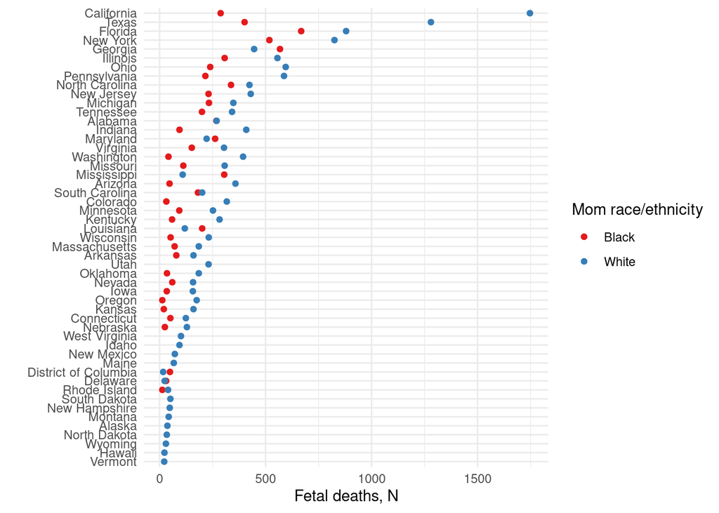

```r
# 1. To do this, first we will create a total fetal deaths variable which will
# reflect the total fetal deaths by state-year. So,to do this, we `group_by`
# state and year and then use `mutate` to create a new variable that is the sum
# of `fetal_deaths` by those grouping vars (state, year)
fetal_data_new <- fetal_data_new %>% group_by(state, year) %>%
  mutate(total_fetal_deaths=sum(fetal_deaths, na.rm=T))

# 2. Let's make a new variable for plotting purposes that has shorter labels.
# We can create a new variable called "mom_race_eth_plot" that replaces "Black or
# African American" with "Black" for simplicity
fetal_data_new <- fetal_data_new %>%
  mutate(mom_race_eth_plot = ifelse(
    mom_race_eth == "Black or African American",
    "Black",
    mom_race_eth
  ))

# 3. Now lets filter to just year 2017! We'll make a new dataframe for plotting
# so that we can preserve the other years of data, too!
fetal_data_plot <- fetal_data_new %>% filter(year == 2017)

# 4. Plot!
ggplot(fetal_data_plot, aes(
    x = fetal_deaths,
    y = reorder(state, total_fetal_deaths),
    color = mom_race_eth_plot
  )) +
  geom_point() +
  theme_minimal() +
  ylab("") + xlab("Fetal deaths, N") +
  scale_color_brewer("Mom race/ethnicity", palette = "Set1")
```

This sort of looks like a plot of total population, we need denominators. Let’s use live births as a denominator.

### IV. Pull in live birth data to use as a denominator, clean, replot!

We will use CDC wonder live births data. This is already in the repo, but you can find it here if you are interested: https://wonder.cdc.gov/natality.html

```r
# Let's bring in live births as our denominator.
births <- read_csv(here("data/lab/01/births.csv"))
glimpse(births)
```

```
## Rows: 664
## Columns: 5
## $ state        <chr> "Alabama", "Alabama", "Alabama", "Alabama", "Alabama", "A…
## $ state_code   <dbl> 1, 1, 1, 1, 1, 1, 1, 1, 1, 1, 1, 1, 1, 2, 2, 2, 2, 2, 2, …
## $ year         <dbl> 2014, 2014, 2014, 2015, 2015, 2015, 2016, 2016, 2016, 201…
## $ mom_race_eth <chr> "Black or African American", "White", NA, "Black or Afric…
## $ births       <dbl> 18417, 39578, 57995, 18429, 39845, 58274, 18488, 39223, 5…
```

```r
# Do we have NAs?
table(births$mom_race_eth, useNA = "always")
```

```
##
## Black or African American                     White                      <NA>
##                       204                       204                       256
```

```r
table(births$year, useNA="always")
```

```
##
## 2014 2015 2016 2017 <NA>
##  153  153  153  153   52
```

```r
table(births$state_code, useNA="always")
```

```
##
##    1    2    4    5    6    8    9   10   11   12   13   15   16   17   18   19
##   13   13   13   13   13   13   13   13   13   13   13   13   13   13   13   13
##   20   21   22   23   24   25   26   27   28   29   30   31   32   33   34   35
##   13   13   13   13   13   13   13   13   13   13   13   13   13   13   13   13
##   36   37   38   39   40   41   42   44   45   46   47   48   49   50   51   53
##   13   13   13   13   13   13   13   13   13   13   13   13   13   13   13   13
##   54   55   56 <NA>
##   13   13   13    1
```

```r
# Let's drop all NAs since we don't need them for this analysis. This will
# drop NAs across all variables in our dataframe `births` and then
# we can double check it.
births <- drop_na(births)
table(births$mom_race_eth, useNA = "always")
```

```
##
## Black or African American                     White                      <NA>
##                       204                       204                         0
```

```r
table(births$year, useNA="always")
```

```
##
## 2014 2015 2016 2017 <NA>
##  102  102  102  102    0
```

```r
table(births$state_code, useNA="always")
```

```
##
##    1    2    4    5    6    8    9   10   11   12   13   15   16   17   18   19
##    8    8    8    8    8    8    8    8    8    8    8    8    8    8    8    8
##   20   21   22   23   24   25   26   27   28   29   30   31   32   33   34   35
##    8    8    8    8    8    8    8    8    8    8    8    8    8    8    8    8
##   36   37   38   39   40   41   42   44   45   46   47   48   49   50   51   53
##    8    8    8    8    8    8    8    8    8    8    8    8    8    8    8    8
##   54   55   56 <NA>
##    8    8    8    0
```

```r
# OK, now let's add total live birth counts to use as the denominator for our
# fetal deaths plot above.
fetal_data_complete <- left_join(fetal_data_new,
                            births,
                            by = c("state" = "state",
                                   "mom_race_eth" = "mom_race_eth",
                                   "year" = "year",
                                   "state_code" = "state_code"))
head(fetal_data_complete)
```

| state | year | mom_race_eth | state_code | fetal_deaths | total_fetal_deaths | mom_race_eth_plot | births |
| --- | --- | --- | --- | --- | --- | --- | --- |
| Alabama | 2014 | Black or African American | 1 | 269 | 522 | Black | 18417 |
| Alabama | 2014 | White | 1 | 253 | 522 | White | 39578 |
| Alabama | 2015 | Black or African American | 1 | 273 | 541 | Black | 18429 |
| Alabama | 2015 | White | 1 | 268 | 541 | White | 39845 |
| Alabama | 2016 | Black or African American | 1 | 262 | 550 | Black | 18488 |
| Alabama | 2016 | White | 1 | 288 | 550 | White | 39223 |

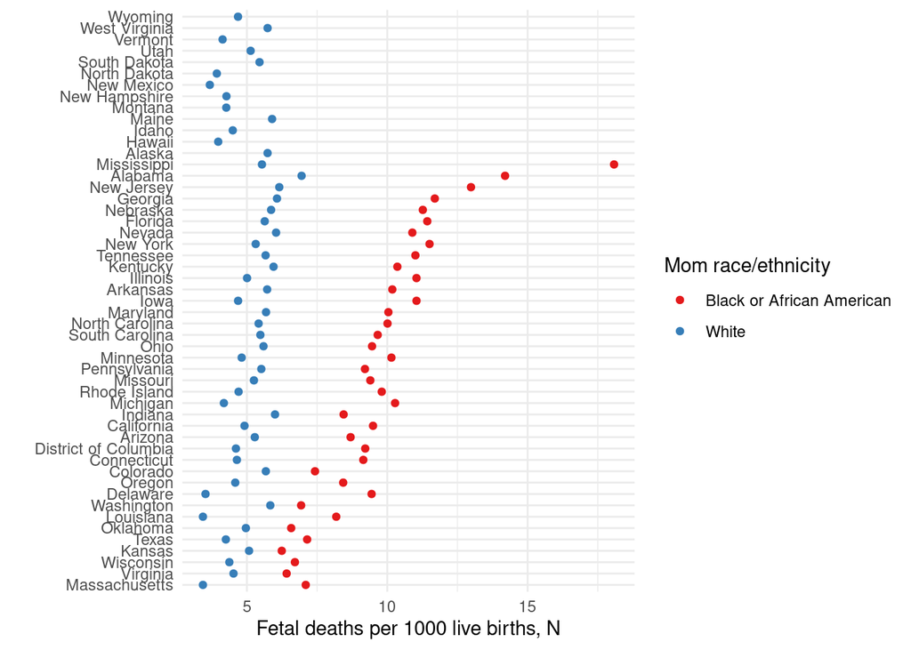

```r
# Create variable scaling fetal deaths by total life births and changing it
# to be per 1,000 live births.
fetal_data_complete <- fetal_data_complete %>%
  mutate(fetal_death_scaled = fetal_deaths/births*1000)

# Now let's visualize prevalence for 2017 again!
fetal_data_plot2 <- fetal_data_complete %>% filter(year == 2017)

ggplot(fetal_data_plot2,
       aes(x = fetal_death_scaled,
           y = reorder(state, fetal_death_scaled),
           color = mom_race_eth)) +
  geom_point() +
  theme_minimal() +
  ylab("") +
  xlab("Fetal deaths per 1000 live births, N") +
  scale_color_brewer("Mom race/ethnicity", palette = "Set1")
```

Much more informative, but what’s happening with states with only white rate?

## Part 2: Mapping

Let’s take a look at the states using a map, which may be easier to interpret!

### I. Read in US states shapefile and join to outcome data

```r
# Reading in a shapefile using st_read
states <- st_read(here("data/lab/01/US_State_Albers.shp"))
head(states)
```

|  | AREA | STATE_NAME | STATE_FIPS | SUB_REGION | STATE_ABBR | POP1990 | POP1996 | cany | geometry |
| --- | --- | --- | --- | --- | --- | --- | --- | --- | --- |
| 1 | 67286.88 | Washington | 53 | Pacific | WA | 4866692 | 5629613 | NA |  |
| 2 | 147236.03 | Montana | 30 | Mtn | MT | 799065 | 885762 | NA |  |
| 3 | 32161.66 | Maine | 23 | N Eng | ME | 1227928 | 1254465 | NA |  |
| 4 | 70810.15 | North Dakota | 38 | W N Cen | ND | 638800 | 633534 | NA |  |
| 5 | 77193.62 | South Dakota | 46 | W N Cen | SD | 696004 | 721374 | NA |  |
| 6 | 97799.49 | Wyoming | 56 | Mtn | WY | 453588 | 487142 | NA |  |

In order to map things, we use data with a CRS. What is the CRS? A CRS is a coordinate reference system and allows us to geolocate places on Earth using coordinates. You must be careful about CRS when working with spatial data! Read more about CRS [here](https://datacarpentry.github.io/organization-geospatial/03-crs.html) and about CRS in R [here](https://rspatial.org/spatial/6-crs.html)

For this project, we will use a projected CRS calledNorth America Albers Equal Area Conic. You can read more [here](http://www.geo.hunter.cuny.edu/~jochen/gtech201/lectures/lec6concepts/Map%20coordinate%20systems/Albers%20Equal%20Area%20Conic.htm)

```r
st_crs(states)
```

```
## Coordinate Reference System:
##   User input: North_America_Albers_Equal_Area_Conic
##   wkt:
## PROJCRS["North_America_Albers_Equal_Area_Conic",
##     BASEGEOGCRS["NAD83",
##         DATUM["North American Datum 1983",
##             ELLIPSOID["GRS 1980",6378137,298.257222101,
##                 LENGTHUNIT["metre",1]]],
##         PRIMEM["Greenwich",0,
##             ANGLEUNIT["Degree",0.0174532925199433]]],
##     CONVERSION["North_America_Albers_Equal_Area_Conic",
##         METHOD["Albers Equal Area",
##             ID["EPSG",9822]],
##         PARAMETER["Latitude of false origin",40,
##             ANGLEUNIT["Degree",0.0174532925199433],
##             ID["EPSG",8821]],
##         PARAMETER["Longitude of false origin",-96,
##             ANGLEUNIT["Degree",0.0174532925199433],
##             ID["EPSG",8822]],
##         PARAMETER["Latitude of 1st standard parallel",20,
##             ANGLEUNIT["Degree",0.0174532925199433],
##             ID["EPSG",8823]],
##         PARAMETER["Latitude of 2nd standard parallel",60,
##             ANGLEUNIT["Degree",0.0174532925199433],
##             ID["EPSG",8824]],
##         PARAMETER["Easting at false origin",0,
##             LENGTHUNIT["metre",1],
##             ID["EPSG",8826]],
##         PARAMETER["Northing at false origin",0,
##             LENGTHUNIT["metre",1],
##             ID["EPSG",8827]]],
##     CS[Cartesian,2],
##         AXIS["(E)",east,
##             ORDER[1],
##             LENGTHUNIT["metre",1]],
##         AXIS["(N)",north,
##             ORDER[2],
##             LENGTHUNIT["metre",1]],
##     USAGE[
##         SCOPE["unknown"],
##         AREA["North America - Canada and USA (CONUS, Alaska mainland)"],
##         BBOX[23.81,-172.54,86.46,-47.74]],
##     ID["ESRI",102008]]
```

```r
# Add the fetal death data to the spatial file by state name (note these are
# different variable names in each dataset)
fetal_spatial <- left_join(states, fetal_data_complete, by = c("STATE_NAME" = "state"))
glimpse(fetal_spatial)
```

```
## Rows: 408
## Columns: 17
## $ AREA               <dbl> 67286.88, 67286.88, 67286.88, 67286.88, 67286.88, 6…
## $ STATE_NAME         <chr> "Washington", "Washington", "Washington", "Washingt…
## $ STATE_FIPS         <chr> "53", "53", "53", "53", "53", "53", "53", "53", "30…
## $ SUB_REGION         <chr> "Pacific", "Pacific", "Pacific", "Pacific", "Pacifi…
## $ STATE_ABBR         <chr> "WA", "WA", "WA", "WA", "WA", "WA", "WA", "WA", "MT…
## $ POP1990            <dbl> 4866692, 4866692, 4866692, 4866692, 4866692, 486669…
## $ POP1996            <dbl> 5629613, 5629613, 5629613, 5629613, 5629613, 562961…
## $ cany               <int> NA, NA, NA, NA, NA, NA, NA, NA, NA, NA, NA, NA, NA,…
## $ year               <dbl> 2014, 2014, 2015, 2015, 2016, 2016, 2017, 2017, 201…
## $ mom_race_eth       <chr> "Black or African American", "White", "Black or Afr…
## $ state_code         <dbl> 53, 53, 53, 53, 53, 53, 53, 53, NA, 30, NA, 30, NA,…
## $ fetal_deaths       <dbl> 52, 393, 42, 373, 42, 365, 42, 394, NA, 39, NA, 43,…
## $ total_fetal_deaths <dbl> 445, 445, 415, 415, 407, 407, 436, 436, 39, 39, 43,…
## $ mom_race_eth_plot  <chr> "Black", "White", "Black", "White", "Black", "White…
## $ births             <dbl> 5254, 70966, 5302, 71041, 5847, 70519, 6059, 67535,…
## $ fetal_death_scaled <dbl> 9.897221, 5.537863, 7.921539, 5.250489, 7.183171, 5…
## $ geometry           <MULTIPOLYGON [m]> MULTIPOLYGON (((-1827715 12..., MULTIP…
```

### II. Make some maps using continuous fetal deaths

For our first map, let’s just subset to 2017 and plot:

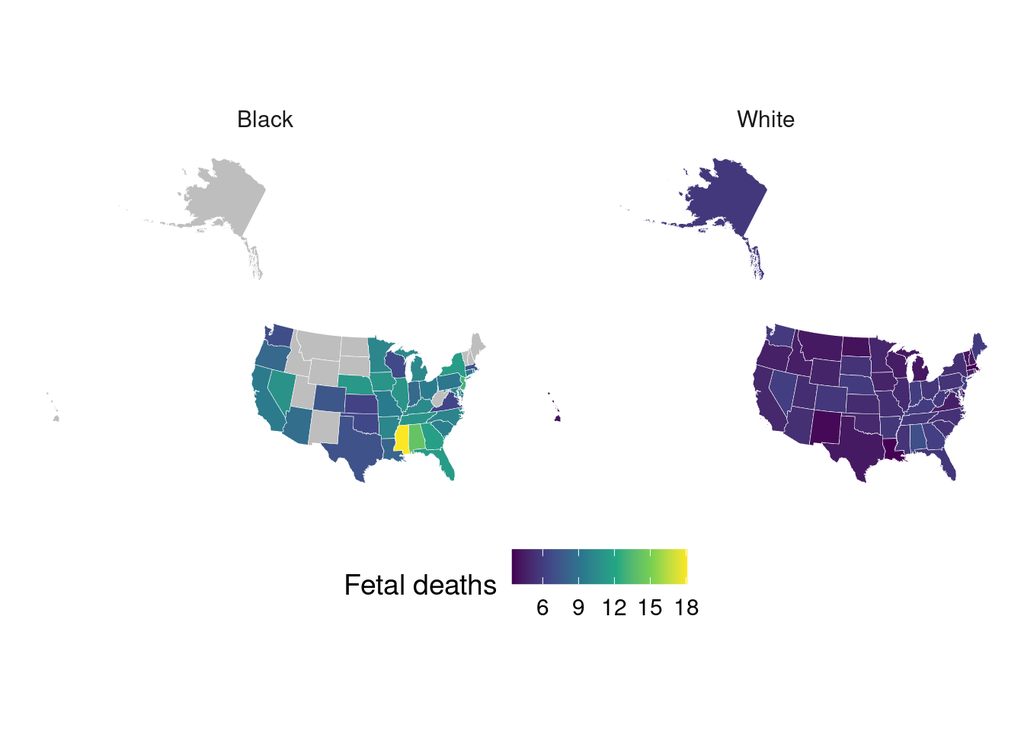

```r
fetal_plot3 <- fetal_spatial %>% filter(year == 2017)

ggplot(fetal_plot3) +
  geom_sf(aes(fill = fetal_death_scaled),
          color = "white",
          lwd = 0.1) +
  scale_fill_viridis_c("Fetal deaths", na.value = "grey") +
  facet_wrap( ~ mom_race_eth_plot) +
  theme_minimal(base_size = 14) +
  theme(
    axis.text.x = element_blank(),
    axis.text.y = element_blank(),
    axis.ticks = element_blank(),
    rect = element_blank()
  ) +
  theme(panel.grid.major = element_blank(),
        # Hide panel borders and remove grid lines
        panel.grid.minor = element_blank()) +
  theme(legend.position = "bottom", legend.box = "horizontal")
```

Let’s try looking at all years. We can map the number of fetal deaths per 1000 live births by race/ethnicity. To plot all years, we can use `facet_grid` and see each year clearly. To read more about this, type `?facet_grid` into your console.

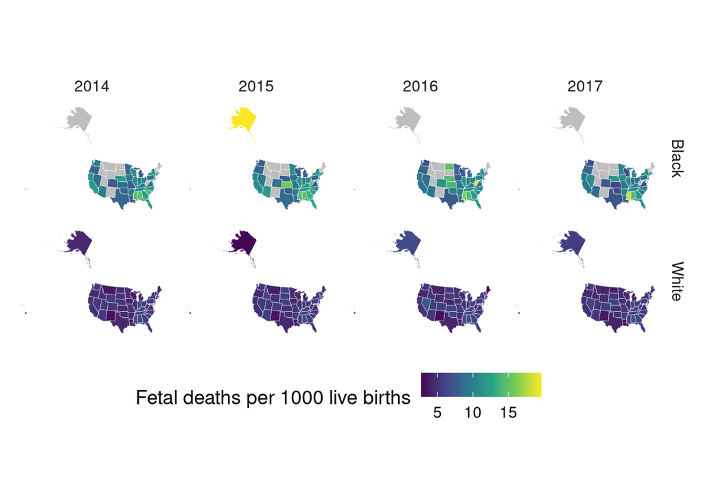

```r
fetal_plot4 <- fetal_spatial # just doing this for consistency

ggplot(fetal_plot4) +
  geom_sf(aes(fill = fetal_death_scaled),
          color = "white",
          lwd = 0.1) +
  scale_fill_viridis_c("Fetal deaths per 1000 live births", na.value = "grey") +
  theme_minimal(base_size = 14) +
  facet_grid(mom_race_eth_plot ~ year) +
  # Does using facet_grid make sense here? Seems no to me as you can't see the
  # variability in white fetal death
  theme(
    axis.text.x = element_blank(),
    axis.text.y = element_blank(),
    axis.ticks = element_blank(),
    rect = element_blank()
  ) +
  theme(panel.grid.major = element_blank(),
        panel.grid.minor = element_blank()) +
  theme(legend.position = "bottom", legend.box = "horizontal")
```

The continuous scale is making it a little harder to see what is happening. Let’s create quintiles for the legend to make it a bit easier!

### III. Reshape data to map quintiles for interpretability

```r
# Let's create quintiles for the legend
qnt <- quantile(fetal_spatial$fetal_death_scaled, c(.2, .4, .6, .8), na.rm = T)
 # take a look at quintiles. we can pull out the values using double brackets.
 # try running this to see what it gives you:
 qnt
```

```
##       20%       40%       60%       80%
##  4.746778  5.591580  7.371913 10.169492
```

```r
 qnt[[1]]
```

```
## [1] 4.746778
```

```r
 qnt[["20%"]]
```

```
## [1] 4.746778
```

```r
 # these are the same so we could use either one!

# Now let's use this to create our quintile variable!
fetal_spatial <- fetal_spatial %>%
  mutate(
    fetal_death_q = case_when(
      fetal_death_scaled < qnt[[1]] ~ 1,
      fetal_death_scaled >= qnt[[1]] &
        fetal_death_scaled < qnt[[2]] ~ 2,
      fetal_death_scaled >= qnt[[2]] &
        fetal_death_scaled < qnt[[3]] ~ 3,
      fetal_death_scaled >= qnt[[3]] &
        fetal_death_scaled < qnt[[4]] ~ 4,
      fetal_death_scaled >= qnt[[4]] ~ 5
    )
  )
qnt_labs <- c(paste('<', round(qnt[[1]], 2)),
              paste0('[', round(qnt[[1]], 2), '-', round(qnt[[2]], 2), ')'),
              paste0('[', round(qnt[[2]], 2), '-', round(qnt[[3]], 2), ')'),
              paste0('[', round(qnt[[3]], 2), '-', round(qnt[[4]], 2), ')'),
              paste('\u2265', round(qnt[[4]], 2)))
# alternate method:
# qnt_labs <- c(paste('<', round(qnt[['20%']], 2)),
#               paste0('[', round(qnt[['20%']], 2), '-', round(qnt[['40%']], 2), ')'),
#               paste0('[', round(qnt[['40%']], 2), '-', round(qnt[['60%']], 2), ')'),
#               paste0('[', round(qnt[['60%']], 2), '-', round(qnt[['80%']], 2), ')'),
#               paste('\u2265', round(qnt[['80%']], 2)))


qnt_labs
```

```
## [1] "< 4.75"       "[4.75-5.59)"  "[5.59-7.37)"  "[7.37-10.17)" "≥ 10.17"
```

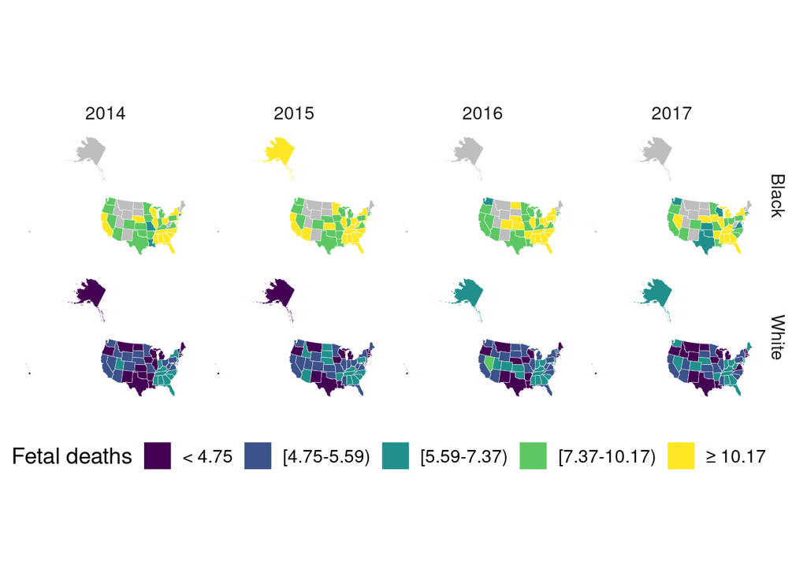

```r
### Alternate method of creating this variable... as a factor with cut()
### No need for case_when() and makes scale_fill_viridis() simpler to use ...
# Note that you need 0 and infinity included as breaks here, whereas you didn't
# need those above! That shifts the numeric indexing of `qnt_alt` to be
# different from that of `qnt`!
# qnt_alt <- c(0, quantile(fetal_spatial$fetal_death_scaled, c(.2, .4, .6, .8), na.rm = T), Inf)
# qnt_labs_alt <- c(paste('<', round(qnt_alt[[2]], 2)),
#               paste0('[', round(qnt_alt[[2]], 2), '-', round(qnt_alt[[3]], 2), ')'),
#               paste0('[', round(qnt_alt[[3]], 2), '-', round(qnt_alt[[4]], 2), ')'),
#               paste0('[', round(qnt_alt[[4]], 2), '-', round(qnt_alt[[5]], 2), ')'),
#               paste('\u2265', round(qnt_alt[[5]], 2)))
# fetal_spatial <-
#   fetal_spatial %>% mutate(
#     fetal_death_q_fctr = cut(
#       x = fetal_death_scaled,
#       breaks = qnt_alt,
#       labels = qnt_labs_alt,
#       right = FALSE,
#       include.lowest = TRUE,
#       ordered = TRUE
#     )
#   )

# Now lets plot our quintiles!
fetal_plot5 <- fetal_spatial

ggplot(fetal_plot5) +
  geom_sf(aes(fill = factor(fetal_death_q)),
          color = "white",
          lwd = 0.1) +
  scale_fill_viridis(
    "Fetal deaths",
    na.value = "grey",
    discrete = T,
    breaks = c(1, 2, 3, 4, 5),
    labels = qnt_labs
  ) +
  theme_minimal(base_size = 14) +
  facet_grid(mom_race_eth_plot ~ year) +
  theme(
    axis.text.x = element_blank(),
    axis.text.y = element_blank(),
    axis.ticks = element_blank(),
    rect = element_blank()
  ) +
  theme(panel.grid.major = element_blank(),
        panel.grid.minor = element_blank()) +
  theme(legend.position = "bottom",
        legend.box = "horizontal")
```

This is the end of class. If you wish to explore cartograms and regression, see below!

## Part 3 (OPTIONAL): Cartograms

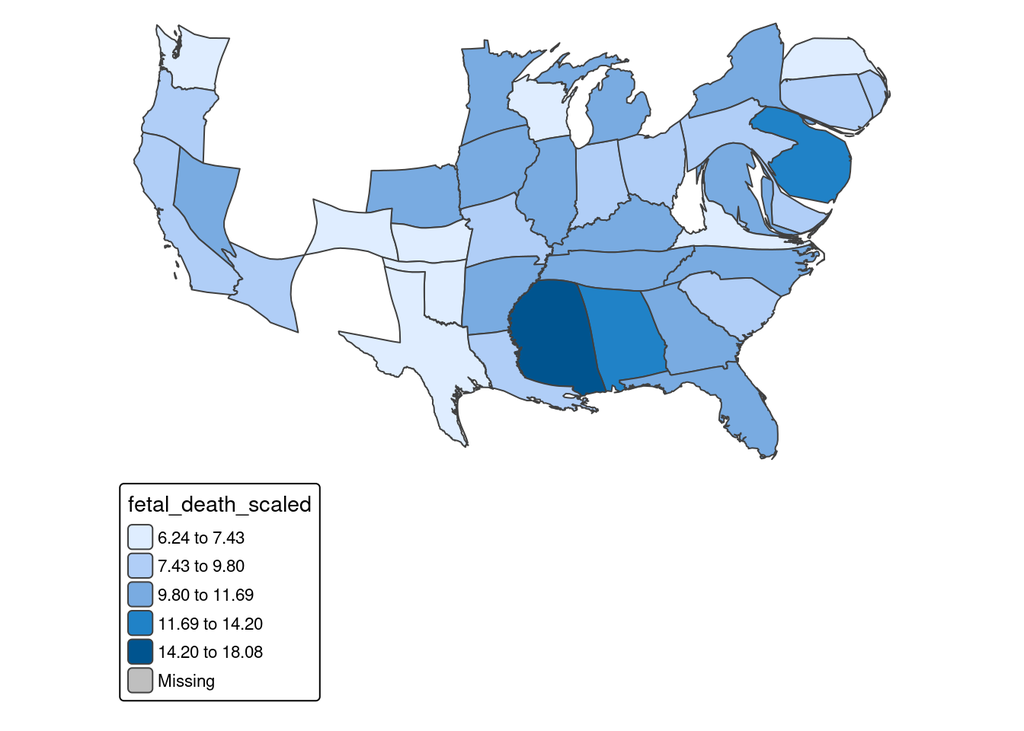

```r
# Cartograms
st_crs(fetal_spatial)
# Look up what this projection is at spatialreference.org
fetal_spatial <- st_transform(fetal_spatial, 2163)
st_crs(fetal_spatial)

# Create cartogram for Black and white fetal deaths in 2017
fetal_spatial_black <- fetal_spatial %>%
  filter(mom_race_eth == "Black or African American" & year == 2017)
fetal_spatial_white <- fetal_spatial %>%
  filter(mom_race_eth == "White" & year == 2017)

fetal_spatial_fetaldeath <- cartogram_cont(fetal_spatial_black, "fetal_death_scaled",
                                    itermax = 10,
                                    threshold = .1)
fetal_spatial_fetaldeath2 <- cartogram_cont(fetal_spatial_white,
                                     "fetal_death_scaled",
                                     itermax = 10,
                                     threshold = .1)

# Plot the cartograms
tm_shape(fetal_spatial_fetaldeath) +
  tm_polygons("fetal_death_scaled", style = "jenks") +
  tm_layout(frame = FALSE, legend.outside = TRUE)
```

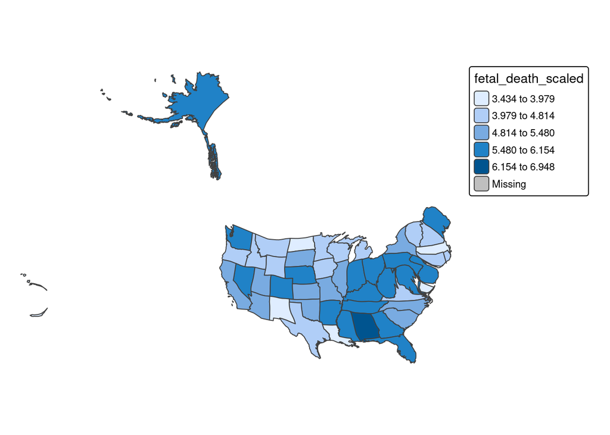

```r
tm_shape(fetal_spatial_fetaldeath2) +
  tm_polygons("fetal_death_scaled", style = "jenks") +
  tm_layout(frame = FALSE, legend.outside = TRUE)
```

## Part 4 (OPTIONAL): Regression

In this part, we will add in information on smoking. These data are in the repo already, but you can find the data we are using, which are cigarette smoking data from the EH Tracking Network, here: https://www.cdc.gov/nceh/tracking/topics/LifestyleRiskFactors.htm

### I. Add in smoking data for analysis

```
## Rows: 612
## Columns: 5
## $ stateFIPS       <dbl> 1, 1, 1, 1, 1, 1, 1, 1, 1, 1, 1, 1, 2, 2, 2, 2, 2, 2, …
## $ state           <chr> "Alabama", "Alabama", "Alabama", "Alabama", "Alabama",…
## $ year            <dbl> 2014, 2014, 2014, 2015, 2015, 2015, 2016, 2016, 2016, …
## $ proportion_smok <dbl> 0.24, 0.27, 0.24, 0.21, 0.30, 0.25, 0.17, 0.30, 0.28, …
## $ age_group       <chr> "18 to 24", "25 to 34", "35 to 44", "18 to 24", "25 to…
```

```
##    Min. 1st Qu.  Median    Mean 3rd Qu.    Max.
## 0.09333 0.16667 0.19667 0.20212 0.23417 0.33667
```

| term | year | prop_smokers | fetal_death_scaled |
| --- | --- | --- | --- |
| year | NA | -0.1646413 | -0.02497877 |
| prop_smokers | -0.16464128 | NA | 0.04795330 |
| fetal_death_scaled | -0.02497877 | 0.0479533 | NA |

[output not shown]

|  | AREA | STATE_NAME | STATE_FIPS | SUB_REGION | STATE_ABBR | POP1990 | POP1996 | cany | year | mom_race_eth | state_code | fetal_deaths | total_fetal_deaths | mom_race_eth_plot | births | fetal_death_scaled | prop_smokers | geometry | percent_smokers |
| --- | --- | --- | --- | --- | --- | --- | --- | --- | --- | --- | --- | --- | --- | --- | --- | --- | --- | --- | --- |
| 1 | 67286.88 | Washington | 53 | Pacific | WA | 4866692 | 5629613 | NA | 2014 | Black or African American | 53 | 52 | 445 | Black | 5254 | 9.897221 | 0.1733333 |  | 17.33333 |
| 2 | 67286.88 | Washington | 53 | Pacific | WA | 4866692 | 5629613 | NA | 2014 | White | 53 | 393 | 445 | White | 70966 | 5.537863 | 0.1733333 |  | 17.33333 |
| 3 | 67286.88 | Washington | 53 | Pacific | WA | 4866692 | 5629613 | NA | 2015 | Black or African American | 53 | 42 | 415 | Black | 5302 | 7.921539 | 0.1600000 |  | 16.00000 |
| 4 | 67286.88 | Washington | 53 | Pacific | WA | 4866692 | 5629613 | NA | 2015 | White | 53 | 373 | 415 | White | 71041 | 5.250489 | 0.1600000 |  | 16.00000 |
| 5 | 67286.88 | Washington | 53 | Pacific | WA | 4866692 | 5629613 | NA | 2016 | Black or African American | 53 | 42 | 407 | Black | 5847 | 7.183171 | 0.1666667 |  | 16.66667 |
| 6 | 67286.88 | Washington | 53 | Pacific | WA | 4866692 | 5629613 | NA | 2016 | White | 53 | 365 | 407 | White | 70519 | 5.175910 | 0.1666667 |  | 16.66667 |

### II. Poisson regression

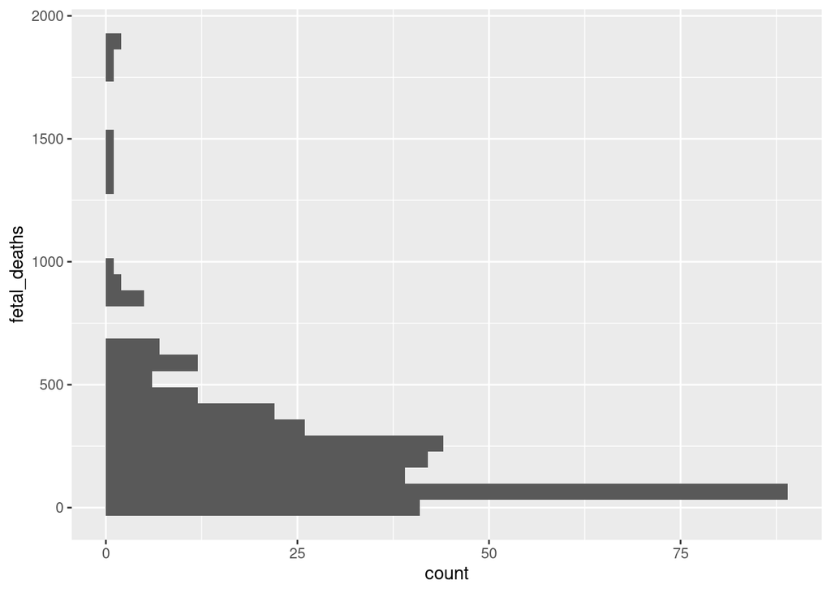

```r
# Basic poisson model
# Check distribution of fetal_deaths
fetal_data_cigs_spatial %>% ggplot(aes(y=fetal_deaths)) + geom_histogram()
```

```r
smoke_poisson <- glm(fetal_deaths ~ percent_smokers + factor(year) +
                       factor(mom_race_eth) + offset(log(births)),
                     data = fetal_data_cigs_spatial, family = poisson(link = "log"))
summary(smoke_poisson)
```

```
##
## Call:
## glm(formula = fetal_deaths ~ percent_smokers + factor(year) +
##     factor(mom_race_eth) + offset(log(births)), family = poisson(link = "log"),
##     data = fetal_data_cigs_spatial)
##
## Coefficients:
##                             Estimate Std. Error  z value Pr(>|z|)
## (Intercept)               -4.6502339  0.0176521 -263.438  < 2e-16 ***
## percent_smokers            0.0052174  0.0007541    6.918 4.57e-12 ***
## factor(year)2015           0.0016867  0.0095178    0.177    0.859
## factor(year)2016           0.0148473  0.0095960    1.547    0.122
## factor(year)2017          -0.0144979  0.0096665   -1.500    0.134
## factor(mom_race_eth)White -0.7196455  0.0073267  -98.222  < 2e-16 ***
## ---
## Signif. codes:  0 '***' 0.001 '**' 0.01 '*' 0.05 '.' 0.1 ' ' 1
##
## (Dispersion parameter for poisson family taken to be 1)
##
##     Null deviance: 10937.3  on 355  degrees of freedom
## Residual deviance:  2038.7  on 350  degrees of freedom
##   (52 observations deleted due to missingness)
## AIC: 4468.8
##
## Number of Fisher Scoring iterations: 4
```

```r
# pull out and exponentiate coefficient
coefficient <- coef(smoke_poisson)[["percent_smokers"]]
exp(coefficient)
```

```
## [1] 1.005231
```

```r
# Is there spatial autocorrelation in the data that we need to account for?
# Let's look at the residuals of our regression model
fetal_data_nomiss <- fetal_data_cigs_spatial %>%
  drop_na(percent_smokers, fetal_deaths, births, mom_race_eth)
fetal_data_nomiss$residuals <- smoke_poisson$residuals
fetal_data_nomiss <- fetal_data_nomiss %>%
  select(year, STATE_NAME, mom_race_eth, residuals, mom_race_eth)
```

### III. Plotting and model diagnostics

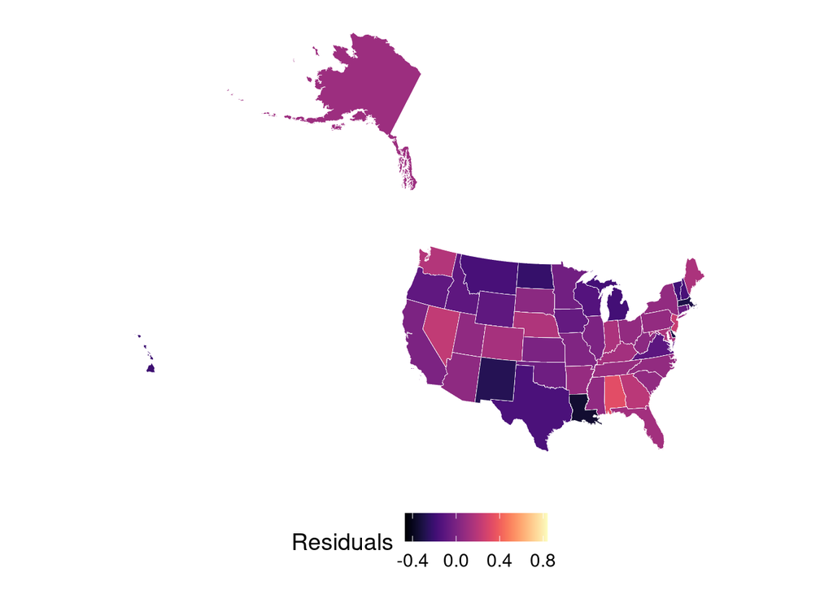

```r
# Is there spatial autocorrelation in the data that we need to account for?
# Let's look at the residuals of our regression model
fetal_data_nomiss <- fetal_data_cigs_spatial %>%
  drop_na(percent_smokers, fetal_deaths, births, mom_race_eth)
fetal_data_nomiss$residuals <- smoke_poisson$residuals
fetal_data_nomiss <- fetal_data_nomiss %>%
  select(year, STATE_NAME, mom_race_eth, residuals, mom_race_eth)


# Do we see a spatial pattern in the residuals?
ggplot(fetal_data_nomiss) +
  geom_sf(aes(fill = residuals),
          color = "white",
          lwd = 0.1) +
  scale_fill_viridis("Residuals",
                     na.value = "grey",
                     option = "A") +
  theme_minimal(base_size = 14) +
  theme(
    axis.text.x = element_blank(),
    axis.text.y = element_blank(),
    axis.ticks = element_blank(),
    rect = element_blank()
  ) +
  theme(panel.grid.major = element_blank(),
        panel.grid.minor = element_blank()) +
  theme(legend.position = "bottom", legend.box = "horizontal")
```

Does it look random?

```r
# Create a neighbor matrix, queen matrix identifying queen-type neighbors
nb <- poly2nb(fetal_data_cigs_spatial, queen = TRUE)

# Assigning weights
lw <- nb2listw(nb, style = "S", zero.policy = TRUE)

# First polygon's weights,
lw$weights[1]
```

```
## [[1]]
##  [1] 0.0331131 0.0331131 0.0331131 0.0331131 0.0331131 0.0331131 0.0331131
##  [8] 0.0331131 0.0331131 0.0331131 0.0331131 0.0331131 0.0331131 0.0331131
## [15] 0.0331131 0.0331131 0.0331131 0.0331131 0.0331131 0.0331131 0.0331131
## [22] 0.0331131 0.0331131
```

```r
# Get Moran's I
set.seed(111)
MC <- moran.mc(fetal_data_cigs_spatial$fetal_death_scaled, lw, na.action = na.exclude, nsim = 500)
MC
```

```
##
##  Monte-Carlo simulation of Moran I
##
## data:  fetal_data_cigs_spatial$fetal_death_scaled
## weights: lw
## omitted: 9, 11, 13, 15, 17, 19, 21, 23, 25, 27, 31, 33, 35, 37, 39, 41, 43, 45, 47, 57, 59, 61, 63, 65, 67, 69, 71, 89, 91, 93, 95, 145, 147, 148, 149, 177, 179, 181, 183, 225, 231, 321, 323, 325, 327, 385, 387, 389, 391, 393, 397, 399
## number of simulations + 1: 501
##
## statistic = 0.068479, observed rank = 501, p-value = 0.001996
## alternative hypothesis: greater
```

We reject the hypothesis that there is no global spatial autocorrelation here.